# Intervalos de confianza y pruebas de hipótesis en R

Jaime Mosquera

2020-12-01

Tomemos unos datos disponibles en R y aprendamos a implementar las procedimientos básicos de inferencia estadística.

## Paquetes necesarios

```r
library(openintro)
library(RcmdrMisc)
library(ggplot2)

# Tema blanco en ggplot2
theme_set(theme_bw())

# if (!require('devtools')) install.packages('devtools')
# devtools::install_github('fhernanb/stests', force=TRUE)
library(stests)
```

## Exploremos los datos

Consideremos los datos de la encuesta del *National Center of Education Statistics.* (EUA).

```r
# Resumen de los datos
str(hsb2)
```

```
## tibble [200 x 11] (S3: tbl_df/tbl/data.frame)
##  $ id     : int [1:200] 70 121 86 141 172 113 50 11 84 48 ...
##  $ gender : chr [1:200] "male" "female" "male" "male" ...
##  $ race   : chr [1:200] "white" "white" "white" "white" ...
##  $ ses    : Factor w/ 3 levels "low","middle",..: 1 2 3 3 2 2 2 2 2 2 ...
##  $ schtyp : Factor w/ 2 levels "public","private": 1 1 1 1 1 1 1 1 1 1 ...
##  $ prog   : Factor w/ 3 levels "general","academic",..: 1 3 1 3 2 2 1 2 1 2 ...
##  $ read   : int [1:200] 57 68 44 63 47 44 50 34 63 57 ...
##  $ write  : int [1:200] 52 59 33 44 52 52 59 46 57 55 ...
##  $ math   : int [1:200] 41 53 54 47 57 51 42 45 54 52 ...
##  $ science: int [1:200] 47 63 58 53 53 63 53 39 58 50 ...
##  $ socst  : int [1:200] 57 61 31 56 61 61 61 36 51 51 ...
```

Exploremos algunas de las variables:

```r
with(hsb2, levels(factor(race)))
```

```
## [1] "african american" "asian"            "hispanic"         "white"
```

```r
with(hsb2, levels(prog))
```

```
## [1] "general"    "academic"   "vocational"
```

Exploremos el desempeño en matemáticas.

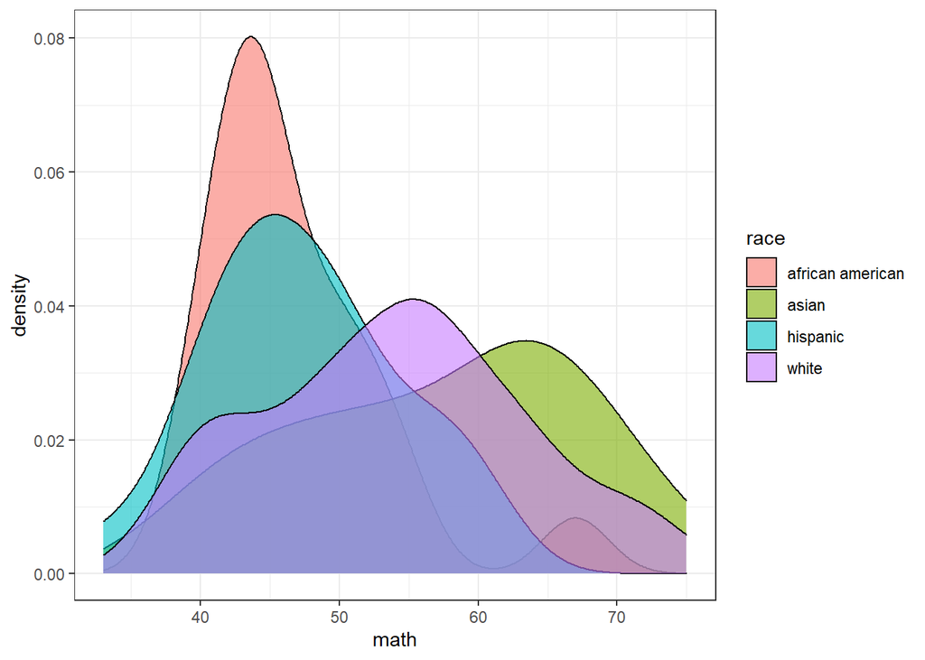

```r
ggplot(data=hsb2, mapping=aes(x=math)) + geom_density(aes(fill=race),
                                                      alpha=0.6)
```

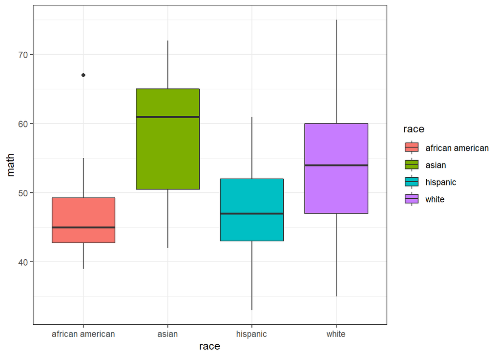

```r
ggplot(data=hsb2, mapping=aes(y=math, x=race)) +
  geom_boxplot(aes(fill=race))
```

### Estadísticos descriptivos

```r
resumen <- numSummary(hsb2[,"math", drop=FALSE], groups=hsb2$race,
  statistics=c("mean", "sd", "IQR", "quantiles", "cv"),
  quantiles=c(0,.25,.5, .75,1))
resumen
```

```
##                      mean        sd  IQR        cv 0%   25% 50%   75% 100%
## african american 46.75000  6.487843  6.5 0.1387774 39 42.75  45 49.25   67
## asian            57.27273 10.120187 14.5 0.1767017 42 50.50  61 65.00   72
## hispanic         47.41667  6.983936  9.0 0.1472886 33 43.00  47 52.00   61
## white            53.97241  9.383011 13.0 0.1738483 35 47.00  54 60.00   75
##                  math:n
## african american     20
## asian                11
## hispanic             24
## white               145
```

## Notación

Hagamos inferencia sobre los parámetros de las poblaciones que confluyen en estos datos. Sea $\theta_{j}^i$ el puntaje promedio e el área $i$ para el grupo $j$, donde:

- $\theta$ es cualquiera de los parámetros que hemos estudiado: $\mu, \sigma, p$
- $i=\lbrace\text{r, w, s, m, ss}\rbrace$, que corresponde a `read, write, science, math, socst` respectivamente.
- $j=\lbrace\text{aa, a, h, w}\rbrace$, que corresponde a `african american, asian, hispanic, white`.

# Inferencia sobre una población

Consideremos la muestra de los hispanos:

```r
hispanic <- hsb2[hsb2$race=='hispanic',]
hispanic
```

```
## # A tibble: 24 x 11
##       id gender race     ses    schtyp prog       read write  math science socst
##    <int> <chr>  <chr>    <fct>  <fct>  <fct>     <int> <int> <int>   <int> <int>
##  1    11 male   hispanic middle public academic     34    46    45      39    36
##  2    20 male   hispanic high   public academic     60    52    57      61    61
##  3    12 male   hispanic middle public vocation~    37    44    45      39    46
##  4    16 male   hispanic low    public vocation~    47    31    44      36    36
##  5     7 male   hispanic middle public academic     57    54    59      47    51
##  6    21 male   hispanic middle public general      44    44    61      50    46
##  7    15 male   hispanic high   public vocation~    39    39    44      26    42
##  8    22 male   hispanic middle public vocation~    42    39    39      56    46
##  9     9 male   hispanic middle public vocation~    48    49    52      44    51
## 10    18 male   hispanic middle public vocation~    50    33    49      44    36
## # ... with 14 more rows
```

## Puntaje promedio para los hispanos en matemáticas

Ya vimos que el promedio muestral tiene como resltado un valor de 47.42. ¿Existe evidencia para afirmar que el puntaje promedio de los hispanos en matemáticas es 50? Usemos un nivel de confianza de 94%.

```r
t.test(hispanic$math, conf.level=0.94, alternative='two.sided',
       mu=50)
```

```
##
##  One Sample t-test
##
## data:  hispanic$math
## t = -1.8121, df = 23, p-value = 0.08305
## alternative hypothesis: true mean is not equal to 50
## 94 percent confidence interval:
##  44.59649 50.23684
## sample estimates:
## mean of x
##  47.41667
```

Como hipótesis, se formula así:

$$\begin{aligned}
H_0&: \mu_{h}^{(m)} = 50 \\
H_1&: \mu_{h}^{(m)} \neq 50
\end{aligned}$$

- Conclusión de la hipótesis: como $valor-p = 0.083 > 0.06$, no se rechaza $H_0$.
- Intervalo de confianza: $\mu_{h}^{(m)} \in (44.6,50.2)$.
- Hagamos la prueba usando estadísticos de resumen, en vez de usar los datos crudos:

```r
meanx <- 47.41667
varx <- 6.983936^2
t_test(meanx=meanx, varx=varx, nx=24, conf.level=0.94,
       mu=50, alternative='two.sided')
```

```
##
##  One Sample t-test
##
## data:  meanx = 47.41667, var = 48.775362052096 and nx = 24
## t = -1.8121, df = 23, p-value = 0.08305
## alternative hypothesis: true mean is not equal to 50
## 94 percent confidence interval:
##  44.59650 50.23684
## sample estimates:
## mean of x
##  47.41667
```

## Proporción de personas que aprobaron

Suponga que el puntaje de corte para aprobar las pruebas es de 50. ¿Es válido afirmar que el 30% de los hombres aprueban en matemáticas?

Vamos a identificar los éxitos.

```r
male <- hsb2[hsb2$gender=='male',]
sucess1 <- male$math > 50
sucess1
```

```
##  [1] FALSE  TRUE FALSE  TRUE  TRUE FALSE FALSE  TRUE  TRUE  TRUE  TRUE  TRUE
## [13]  TRUE FALSE FALSE  TRUE  TRUE  TRUE  TRUE FALSE  TRUE FALSE  TRUE FALSE
## [25] FALSE  TRUE  TRUE FALSE FALSE  TRUE  TRUE  TRUE  TRUE FALSE  TRUE  TRUE
## [37]  TRUE FALSE FALSE FALSE  TRUE  TRUE FALSE FALSE  TRUE FALSE  TRUE  TRUE
## [49]  TRUE  TRUE FALSE  TRUE FALSE  TRUE FALSE FALSE FALSE  TRUE  TRUE FALSE
## [61]  TRUE FALSE FALSE FALSE FALSE  TRUE FALSE  TRUE FALSE FALSE  TRUE  TRUE
## [73]  TRUE FALSE FALSE  TRUE  TRUE FALSE  TRUE  TRUE  TRUE  TRUE FALSE FALSE
## [85]  TRUE  TRUE FALSE FALSE  TRUE  TRUE FALSE
```

Ahora, vamos a contarlos.

```r
# Número de éxitos
x1 <- sum(sucess1)
x1
```

```
## [1] 51
```

Además, sabemos que $n=91$. Entonces, usando un nivel de confianza de 93%:

```r
prop.test(x=x1, n=nrow(male), conf.level=0.93,
          alternative='two.sided', p=0.3)
```

```
##
##  1-sample proportions test with continuity correction
##
## data:  x1 out of nrow(male), null probability 0.3
## X-squared = 28.165, df = 1, p-value = 1.114e-07
## alternative hypothesis: true p is not equal to 0.3
## 93 percent confidence interval:
##  0.4602753 0.6561537
## sample estimates:
##         p
## 0.5604396
```

# Comparaciones (Inferencia sobre dos poblaciones)

Ahora, también consideremos la muestra de los afroamericanos.

```r
africanam <- hsb2[hsb2$race=='african american',]
africanam
```

```
## # A tibble: 20 x 11
##       id gender race       ses    schtyp prog     read write  math science socst
##    <int> <chr>  <chr>      <fct>  <fct>  <fct>   <int> <int> <int>   <int> <int>
##  1    50 male   african a~ middle public general    50    59    42      53    61
##  2    48 male   african a~ middle public academ~    57    55    52      50    51
##  3    38 male   african a~ low    public academ~    45    57    50      31    56
##  4    41 male   african a~ middle public academ~    50    40    45      55    56
##  5    53 male   african a~ middle public vocati~    34    37    46      39    31
##  6    40 male   african a~ low    public general    42    41    43      50    41
##  7    49 male   african a~ high   public vocati~    50    40    39      49    47
##  8    47 female african a~ low    public academ~    47    46    49      33    41
##  9    54 female african a~ low    priva~ general    47    54    46      50    56
## 10    37 female african a~ low    public vocati~    41    47    40      39    51
## 11    44 female african a~ low    public vocati~    47    62    45      34    46
## 12    45 female african a~ low    public vocati~    34    35    41      29    26
## 13    42 female african a~ middle public vocati~    46    52    55      44    56
## 14    55 female african a~ middle priva~ academ~    52    49    49      44    61
## 15    46 female african a~ low    public academ~    45    55    44      34    41
## 16    43 female african a~ low    public academ~    47    37    43      42    46
## 17    39 female african a~ high   public academ~    66    67    67      61    66
## 18    51 female african a~ high   public general    42    36    42      31    39
## 19    36 female african a~ low    public general    44    49    44      35    51
## 20    52 female african a~ low    public academ~    50    46    53      53    66
```

## Cociente de Varianzas

Como pudimos ver en la exploración de datos, $S_h^{(m)}=6.98$ y $S_{aa}^{(m)}=6.49$. ¿Tienen realmente la misma dispersión?

```r
var.test(hispanic$math, africanam$math, alternative='two.sided')
```

```
##
##  F test to compare two variances
##
## data:  hispanic$math  and  africanam$math
## F = 1.1588, num df = 23, denom df = 19, p-value = 0.7511
## alternative hypothesis: true ratio of variances is not equal to 1
## 95 percent confidence interval:
##  0.4701324 2.7514766
## sample estimates:
## ratio of variances
##           1.158777
```

Como hipótesis, se formula así:

$$\begin{aligned}
H_0&: \sigma_{h}^{2\:(m)} = \sigma_{aa}^{2\:(m)} \\
H_1&: \sigma_{h}^{2\:(m)} \neq \sigma_{aa}^{2\:(m)}
\end{aligned}$$

- Conclusión de la hipótesis: como $valor-p = 0.751 > 0.05$, no se rechaza $H_0$.
- Intervalo de confianza: $\sigma_h^{2\:(m)} / \sigma_{aa}^{2\:(m)} \in (0.47,2.75)$.
- Hagamos la prueba usando estadísticos de resumen, en vez de usar los datos crudos:

```r
varx <- 6.983936^2
vary <- 6.487843^2
var_test(varx=varx, vary=vary, nx=24, ny=20,
         alternative='two.sided')
```

```
##
##  F test to compare two variances
##
## data:  varx = 48.775362052096 , nx = 24 , vary = 42.092106792649 and ny = 20
## F = 1.1588, num df = 23, denom df = 19, p-value = 0.7511
## alternative hypothesis: true ratio of variances is not equal to 1
## 95 percent confidence interval:
##  0.4701323 2.7514765
## sample estimates:
## ratio of variances
##           1.158777
```

## Diferencia de medias

Recordemos que $\bar{X}_h^m=47.42$ y $\bar{X}_a^m=46.75$. ¿Es realmente diferente el puntaje promedio de ambos grupos? Usemos un 95% de confianza.

```r
t.test(hispanic$math, africanam$math, conf.level=0.95,
       var.equal=TRUE, alternative='two.sided')
```

```
##
##  Two Sample t-test
##
## data:  hispanic$math and africanam$math
## t = 0.32554, df = 42, p-value = 0.7464
## alternative hypothesis: true difference in means is not equal to 0
## 95 percent confidence interval:
##  -3.466181  4.799515
## sample estimates:
## mean of x mean of y
##  47.41667  46.75000
```

Como hipótesis, se formula así:

$$\begin{aligned}
H_0&: \mu_{h}^{(m)} - \mu_{aa}^{(m)} = 0 \\
H_1&: \mu_{h}^{(m)} - \mu_{aa}^{(m)} \neq 0
\end{aligned}$$

```r
meanx <- 47.41667
varx <- 6.983936^2
meany <- 46.750
vary <- 6.487843^2
t_test(meanx=meanx, varx=varx, meany=meany, vary=vary,
       nx=24, ny=20, alternative='two.sided')
```

```
##
##  Welch Two Sample t-test
##
## data:  meanx = 47.41667, nx = 24, meany = 46.75 and ny = 20
## t = 0.32777, df = 41.468, p-value = 0.7447
## alternative hypothesis: true difference in means is not equal to 0
## 95 percent confidence interval:
##  -3.439547  4.772887
## sample estimates:
## mean of x mean of y
##  47.41667  46.75000
```

## Diferencia de proporciones

Ahora, determinemos si hay diferencia en la proporción de personas que aprobaron según el género.

```r
female <- hsb2[hsb2$gender=='female',]
success2 <- female$math > 50
success2
```

```
##   [1]  TRUE  TRUE  TRUE FALSE  TRUE  TRUE  TRUE FALSE  TRUE  TRUE  TRUE FALSE
##  [13]  TRUE  TRUE  TRUE  TRUE FALSE FALSE  TRUE FALSE FALSE  TRUE  TRUE  TRUE
##  [25] FALSE  TRUE  TRUE  TRUE FALSE FALSE FALSE  TRUE  TRUE FALSE  TRUE FALSE
##  [37]  TRUE  TRUE FALSE  TRUE  TRUE  TRUE FALSE FALSE  TRUE  TRUE  TRUE FALSE
##  [49] FALSE FALSE FALSE  TRUE FALSE  TRUE FALSE FALSE FALSE FALSE FALSE FALSE
##  [61]  TRUE FALSE FALSE  TRUE  TRUE FALSE  TRUE FALSE  TRUE  TRUE FALSE  TRUE
##  [73]  TRUE FALSE FALSE  TRUE FALSE  TRUE  TRUE FALSE FALSE FALSE  TRUE FALSE
##  [85]  TRUE  TRUE  TRUE FALSE  TRUE FALSE FALSE  TRUE  TRUE  TRUE  TRUE  TRUE
##  [97] FALSE  TRUE  TRUE FALSE FALSE  TRUE FALSE  TRUE  TRUE FALSE  TRUE  TRUE
## [109]  TRUE
```

```r
x2 <- sum(success2)
x2
```

```
## [1] 62
```

y ahora podemos aplicar una prueba para la diferencia de proporciones.

```r
nm <- nrow(male)
nf <- nrow(female)
prop.test(x=c(x1, x2), n=c(nm, nf), alternative='two.sided')
```

```
##
##  2-sample test for equality of proportions with continuity correction
##
## data:  c(x1, x2) out of c(nm, nf)
## X-squared = 4.6793e-30, df = 1, p-value = 1
## alternative hypothesis: two.sided
## 95 percent confidence interval:
##  -0.1547322  0.1379967
## sample estimates:
##    prop 1    prop 2
## 0.5604396 0.5688073
```